# VL03: Gradientenabstieg, Evolutionäre Algorithmen

IFM 5.6 Künstliche Intelligenz, 2017/18

Carsten Gips, FH Bielefeld

# Wiederholung

## Eigenschaften von Suchverfahren

- Wie kann man mit Tiefensuche den optimalen Weg finden?
- Was bedeutet Backtracking? Wie wird das implementiert?
- Welche Bedingung muss erfüllt sein, damit $A^\star$ optimal ist?

**Wahr oder falsch?**

1. Breitensuche ist ein Spezialfall von Branch-and-Bound.
2. Tiefensuche ist ein Spezialfall von Best-First (Tree-Search-Variante).
3. Branch-and-Bound ist ein Spezialfall von $A^\star$.

# Motivation

## Unterschiede in den Suchproblemen?

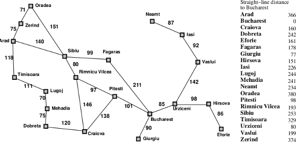

Quelle: [AIMA 3rd ed.](http://aima.cs.berkeley.edu)

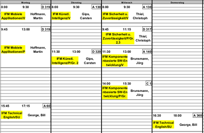

Bisher betrachtete Suchverfahren:

- Systematische Erkundung des Suchraums
- Weg zur Lösung wichtig

=> Oft aber nur das Ziel **an sich** interessant! (Und nicht, wie man dort hin gelangt.)

Beispiel: Stundenplan

## Themen für heute

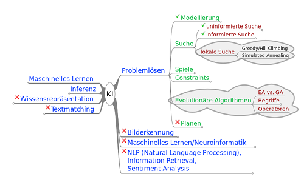

Am Ende der VL können/verstehen Sie:

- Lokale Suche: Greedy Suche und Simuliertes Abkühlen
- Einblick in die Welt der Evolutionären Algorithmen

# Lokale Suche

## Analogie: Bergsteigen ohne Karte und Pfade

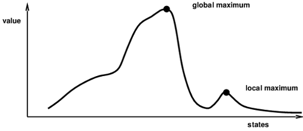

Quelle: [AIMA 3rd ed.](http://aima.cs.berkeley.edu)

**Gradienten-Suche**: “Gehe in Richtung des steilsten Anstiegs der Zielfunktion .”

=> Schrittweise Verbesserung des aktuellen Zustands (Lokale Suche)

- Verschiedene Namen: “Hill-climbing”, “Greedy local search”
- Kann auch als Minimierung angewendet werden

## Pseudoalgorithmus Gradientensuche

“Wie Bergsteigen am Mount Everest in dickem Nebel mit Gedächtnisverlust.”

1. Setze `currNode` auf den Startknoten
2. `currNode` ist gesuchtes Element: Abbruch, melde “*gefunden*”
   1. Expandiere alle Nachfolger von `currNode`
   2. Setze `nextNode` auf Nachfolger mit höchster Bewertung
   3. Falls Bewertung von `nextNode` $\leq$ Bewertung von `currNode`: Abbruch, melde “*nicht gefunden*”
   4. Setze `currNode` auf `nextNode`
3. Gehe zu Schritt 2

## Gradientensuche: Finde Weg von Rimnicu nach Bucharest

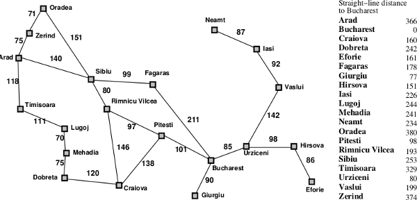

Quelle: [AIMA 3rd ed.](http://aima.cs.berkeley.edu)

Tafelbeispiel Gradientensuche, Bewertung: Restkostenschätzung

### Beispiel Gradientensuche: $n$-Damen

- Ziel: Setze $n$ Damen auf ein $n \times n$-Spielfeld ohne Konflikte
- Suche: Bewege eine Dame so, daß die Anzahl der Konflikte reduziert wird

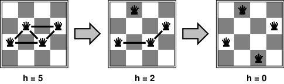

  Quelle: [AIMA 3rd ed.](http://aima.cs.berkeley.edu)

*Hinweis*: Alle Damen von Anfang an auf dem Brett, werden nur verschoben

=> “vollständige Zustandsformulierung ”

### Eigenschaften Gradientensuche

Beispiel 8-Damen-Problem ($n=8$)

- Zustandsraum: $8^8 \approx 17$ Millionen Zustände! (Quelle: RN03 “AIMA”)
- Beginnend mit zufällig erzeugtem Startzustand:
  - bleibt in 86% der Fälle stecken, d.h.
  - findet Lösung nur in 14% der Fälle.

  Aber:
  - Lösung nach durchschnittlich 4 Schritten, oder
  - bleibt nach durchschnittlich 3 Schritten stecken.

## Zielfunktion und Zustandsraum-Landschaft

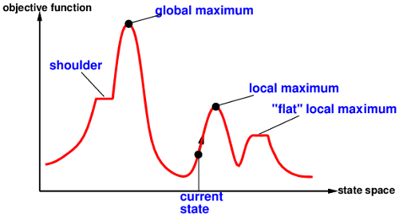

Quelle: [AIMA 3rd ed.](http://aima.cs.berkeley.edu)

## Eigenschaften Gradientensuche

- Vollständigkeit: nein
- Optimalität: nein
- Komplexität: linear in der Anzahl der zu expandierenden Knoten

Zielfunktion (Bewertung) nötig!

**Probleme**: lokale Maxima und Plateaus

- Lokale Maxima/Minima: Algorithmus findet nur eine suboptimale Lösung
- Plateaus: Hier muss der Algorithmus mit zufälligen Zügen explorieren

Mögliche Lösungen:

- Neustart des Algorithmus, wenn kein Fortschritt erzielt wird
- Rauschen “injizieren”

## Gedankenexperiment: Ausweg aus lokalen Minima

- Ball wird in Zustandsraum-Landschaft gesetzt.
- Folge:
  - rollt steilsten Abstieg hinunter
  - rollt evtl. in Tal auf halber Höhe (lokales Minimum) => bleibt dort gefangen

=> “Schütteln der Landschaft” – Ball springt aus dem Tal und rollt in anderes Tal

Nicht zu stark schütteln – sonst wird u.U. globales Minimum verlassen!

## Analogie Härten von Metall

- Metall erhitzen bis Atome frei beweglich
- Langsam abkühlen

  => stabiles Atomgitter mit minimalem Energiezustand

## Übertragen der Idee

- Starkes “Schütteln” (hohe “Temperatur”) am Anfang
- Schrittweises “Abkühlen” => “Schütteln” im Laufe der Zeit verringern

=> Simulated Annealing

## Pseudocode Simulated Annealing

```python
def simulated_annealing(problem):
    current = problem.startNode
    t = 0;  temp = schedule(t)

    while temp>0:
        temp = schedule(++t)
        neighbors = current.expandSuccessors()
        if not neighbors: return current
        working = random.choice(neighbors)
        dE = problem.value(working) - problem.value(current)
        if dE > 0 or probability(math.exp(dE/temp)):
            current = working

    return current
```

`dE` negativ: $\exp\left(\text{dE}/\text{temp}\right) = \exp\left(-\frac{|\text{dE}|}{\text{temp}}\right) = \frac{1}{\exp\left(\frac{|\text{dE}|}{\text{temp}}\right)}$

Abkühlungsplan problemabhängig wählen:

- Initiale Temperatur: So hoch, daß praktisch jede Änderung akzeptiert wird
- Abkühlen: $T_k = \alpha T_{k-1}$ mit $0.8 \le \alpha \le 0.99$
  - Ausreichend langsam abkühlen!
  - Typisch: jede Stufe so lange halten, daß etwa 10 Änderungen akzeptiert wurden
- Stop: Keine akzeptierten Änderungen in 3 aufeinander folgenden Temperaturen

## Eigenschaften Simulated Annealing

- Vollständigkeit: ja (mit gewisser Wahrscheinlichkeit)
- Optimalität: ja (mit gewisser Wahrscheinlichkeit)

Voraussetzung: geeigneter Abkühlungsplan

## Anwendungen von Simulated Annealing

- Flugplan-Scheduling
- Layout-Probleme (Chipentwurf, Leiterplatten)
- Produktionsplanung

# Evolutionäre Algorithmen

## Evolution sehr erfolgreich bei Anpassung

[figure not shown]

Quelle: wikipedia.de

Wie funktionierts?

kurze Diskussion

## EA – Zutaten und Mechanismen

- Zutaten:
  - **Individuen**: Kodierung möglicher Lösungen
  - **Population** von Individuen
  - **Fitnessfunktion**: Bewertung der Angepasstheit
- Mechanismen (“Operatoren”):
  - Selektion
  - Rekombination (Crossover)
  - Mutation

## EA – Allgemeiner Ablauf

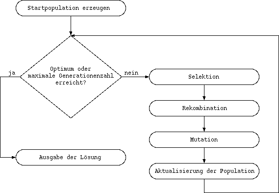

## EA – Beispiel

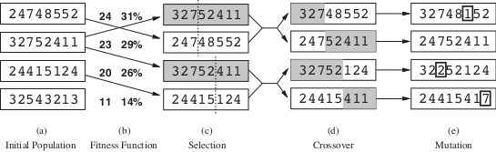

Quelle: [AIMA 3rd ed.](http://aima.cs.berkeley.edu)

Jedes Individuum kodiert ein Spielfeld mit einer konkreten Anordnung **aller** Königinnen.

Dabei korrespondiert der Index in das Array des Individuums mit der jeweiligen Spalte des Spielfelds. Die Zahl an einer Arrayposition gibt dann an, in welcher Zeile in dieser Spalte eine Königin ist.

**Vollständige Zustandsbeschreibung**

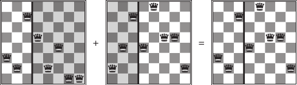

Quelle: [AIMA 3rd ed.](http://aima.cs.berkeley.edu)

Crossover: Die ausgewählten Individuen werden an der selben Stelle aufgetrennt und die Hälften verkreuzt zu zwei neuen Individuen zusammengesetzt. Es enstehen zwei neue Anordnungen der Königinnen (zwei neue Spielfelder).

## EA – Strömungen

1. **Genetische Algorithmen** (GA)
   - Holland und Goldberg (ab 1960)
   - Binäre Lösungsrepräsentation (Bitstring): $\mathbf{g} = (g_1, \dots, g_m)\in \{ 0,1\}^m$
   - Fitnessbasierte stochastische Selektion
   - $\mu$ Eltern erzeugen $\mu$ Kinder
2. **Evolutionsstrategien** (ES)
   - Rechenberg und Schwefel (ab 1960)
   - Kodierung reellwertiger Parameter: $\mathbf{g} = (\mathbf{x}, \sigma)$ mit $\mathbf{x} = (x_1, \dots, x_n) \in \mathbb{R}^n$
   - $\mu$ Eltern erzeugen $\lambda$ Kinder mit $\mu \le \lambda$
3. **Evolutionäre Programmierung** (EP)

*Hinweis*: Häufig finden sich Mischformen, beispielsweise GA mit reellwertigen Parametern

*Hinweis*: Im Folgenden werden **Genetische Algorithmen** (GA) betrachtet. Sie finden jeweils Hinweise auf die Gestaltung der Operatoren bei ES.

### Anwendungsbeispiele für Evolutionäre Algorithmen

- Berechnung und Konstruktion komplexer Bauteile: beispielsweise Tragflächenprofile (Flugzeuge), Brücken oder Fahrzeugteile unter Berücksichtigung bestimmter Nebenbedingungen
- Scheduling-Probleme: Erstellung von Stunden- und Raumplänen oder Fahrplänen
- Berechnung verteilter Netzwerktopologien: Wasserversorgung, Stromversorgung, Mobilfunk
- Layout elektronischer Schaltkreise

## Kodierung Individuen

- Binäre Lösungsrepräsentation (Bitstring): $\mathbf{g} = (g_1, \dots, g_m)\in \{ 0,1\}^m$
  - String gliedert sich in $n$ Elemente (mit $n \le m$) => jedes Segment entspricht einer Problemvariablen
  - Dekodierungsfunktion $\Gamma : \{0,1\}^m \to \mathbb{R}^n$

  Alle relevanten Aspekte des Problems müssen in die Codierung einfliessen!

  Bei ES hat man einen Vektor mit reellen Zahlen, wobei jeder Eintrag einen Parameter des Problems darstellt. Eine Dekodierungsfunktion benötigt man entsprechend nicht.

  Bei der Erzeugung der Startpopulation werden die Individuen **zufällig** (mit zufälligen Werten) initialisiert.
- Fitnessfunktion $\Phi$ ordnet jedem Individuum $\mathbf{g}_i$ eine reelle Zahl zu:
  $$\Phi(\mathbf{g}_i) = F(\Gamma(\mathbf{g}_i)) - w\cdot\sum_j(Z_j(\Gamma(\mathbf{g}_i)))^2$$
  - Zielfunktion $F$: wie sehr genügt ein Individuum bereits dem Optimierungproblem
  - Strafterme $Z_j$: Anreicherung der Optimierung mit weiteren Informationen
  - Gewichte $w$: statisch oder dynamisch (Abkühlen)

  Die Wahl einer guten Fitnessfunktion ist oft eine Herausforderung, aber dennoch wichtig, da damit die Suche gesteuert wird!

## Selektion: Erstelle Matingpool mit $\mu$ Individuen

- Fitnessproportionale Selektion (*Roulette Wheel Selection*):Auswahlwahrscheinlichkeit für Individuum $\mathbf{g}_k$
  $$p_{sel}(\mathbf{g}_k) = \frac{\Phi(\mathbf{g}_k)}{\sum_j \Phi(\mathbf{g}_j)}$$
  => Voraussetzung: positive Fitnesswerte
- Turnier-Selektion (*Tournament Selection*):
  - Turniergröße $\xi$
  - Turnier: ziehe $\xi$ Individuen gleichverteilt (mit Zurücklegen!) und kopiere fittestes Individuum in den Matingpool
  - Führe $\mu$ Turniere durch

*Hinweis*: Es gibt noch viele weitere Selektionsmechanismen. Die vorgestellten sind in der Praxis am gebräuchlichsten.

Über die Selektion wird der sogenannte “Selektionsdruck” aufgebaut: Wie gut muss ein Individuum sein (im Vergleich zu den restlichen Individuen in der Population), damit es eine Chance zur Reproduktion erhält? Dürfen sich nur die “Guten” fortpflanzen, oder erhalten auch die “Schlechten” eine gewisse Chance?

Da jedes Individuum einen Punkt im Suchraum darstellt, beeinflusst die Wahl der Selektion die Geschwindigkeit der Suche, begünstigt u.U. aber auch ein eventuelles Festfahren in lokalen Minima. Dies kann beispielsweise geschehen, wenn immer nur die “Guten” selektiert werden, aber die “Guten” der Population sich in der Nähe eines lokalen Minimums befinden. Dann werden auch die Nachfolger sich wieder dort aufhalten.

## Crossover: Erzeuge zwei Nachkommen aus zwei Eltern

Festlegung der Crossover-Wahrscheinlichkeit $p_{cross}$ (typisch: $p_{cross} \ge 0.6$)

1. Selektiere Eltern $\mathbf{g}_a$ und $\mathbf{g}_b$ **gleichverteilt** aus Matingpool
2. Zufallsexperiment:
   - mit $1-p_{cross}$: Kinder identisch zu Eltern (kein Crossover)
   - mit $p_{cross}$: Crossover mit $\mathbf{g}_a$ und $\mathbf{g}_b$
     - Ziehe $i$ gleichverteilt mit $1 < i < m$
     - Kinder aus $\mathbf{g}_a$ und $\mathbf{g}_b$ zusammenbauen:$\mathbf{g}_c = (g_{a,1}, \dots, g_{a,i}, \; g_{b,{i+1}}, \dots, g_{b,m})$ und $\mathbf{g}_d = (g_{b,1}, \dots, g_{b,i}, \; g_{a,{i+1}}, \dots, g_{a,m})$

     => Trenne Eltern an gleicher Stelle auf, vertausche Bestandteile
3. Gehe zu Schritt 1, bis insg. $\mu$ Nachkommen

*Anmerkung*: Die Eltern werden jeweils in die Ausgangsmenge zurückgelegt.

Mit einer kleinen Wahrscheinlichkeit sind die Kinder also identisch zu den Eltern. Dies ist im Sinne der lokalen Suche wichtig, um bereits erreichte gute Positionen im Suchraum nicht zu verlieren: Es könnte sein, dass die Nachfolger alle schlechter sind …

Varianten: $N$-Punkt-Crossover, Shuffle-Crossover

Bei ES wird parameterweise gekreuzt. Dabei gibt es verschiedene Möglichkeiten: Übernahme eines Parameters von einem Elternteil, Verrechnen (beispielsweise Mitteln) der Werte beider Eltern, … Bei ES heisst “Crossover” deshalb oft “Rekombination”.

## Mutation

- Mutationswahrscheinlichkeit $p_{mut}$(typische Werte: $p_{mut} = 0.01$ oder $p_{mut} = 0.001$)
- Für alle Individuen:
  - Mutiere jedes Gen eines Individuums mit $p_{mut}$:

    $$g_i^{(t+1)} = \left\{
    \begin{array}{ll}
    \neg g_i^{(t)} & \mbox{ falls } \chi_i \le p_{mut}\\[5pt]
    \;\:\, g_i^{(t)} & \mbox{ sonst }
    \end{array}
    \right.$$

    => $\chi_i$ gleichverteilte Zufallsvariable (Intervall $[0,1]$), für jedes Bit $g_i$ neu bestimmen

*Anmerkung*: Die optimale Mutationsrate $p_{mut}^*$ ist von Länge $m$ des Bitstrings abhängig; annäherbar durch $p_{mut}^* \approx 1/m$.

Die beim Crossover erstellten Nachfolger liegen im Suchraum in der Nähe der Eltern. Durch die Mutationsrate bestimmt man, ob und wie weit sich ein Kind entfernen kann. Dies entspricht dem Bild des “Schüttelns” der Zustandslandschaft.

Bei ES unterscheidet man Mutationswahrscheinlichkeit und Mutationsrate. Es wird parameterweise mutiert.

### Bewertungskriterien

Vorsicht: Es handelt sich um Zufallsexperimente. Wenn man nicht nur direkt nach einer Lösung sucht, sondern beispielsweise Parametereinstellungen oder die Wahl der Fitnessfunktion für ein Problem vergleichen will, muss man jeweils mehrere Experimente mit der selben Einstellung machen und Kenngrößen berechnen.

**Geschwindigkeit: AES** *Average Evaluations to a Solution*
$$\mbox{AES } = \frac{\sum\limits_{i \in \mbox{erfolgreiche Läufe}} \mbox{Generationen von Lauf } i}{\mbox{Anzahl der erfolgreichen Läufe}}$$

Die AES liegt im Intervall $[0, maxGen]$.

**Lösungswahrscheinlichkeit: SR** *Success Rate*
$$\mbox{SR } = \frac{\mbox{Anzahl der erfolgreichen Läufe}}{\mbox{Anzahl aller Läufe}}$$

Die SR liegt im Intervall $[0, 1]$.

## Typische Läufe

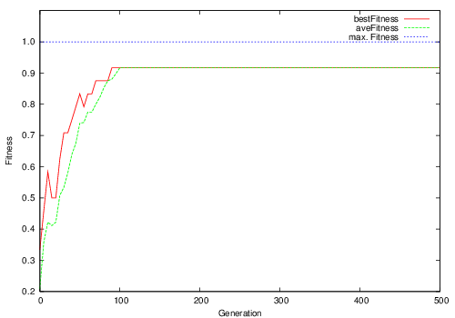

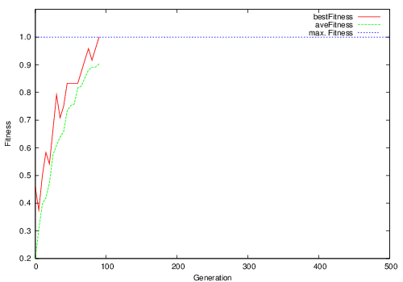

Stochastischer Algorithmus! Ausreichend Wiederholungen durchführen und mitteln!

*Hinweis*: Die Parameter müssen problemabhängig gewählt werden. Zu hohe Werte für $\mu$ und $\lambda$ führen dazu, dass man bei kleinen Problemen mit hoher Wahrscheinlichkeit bereits am Anfang eine Lösung “würfelt”, also gar kein GA nutzt. Wenn dies allerdings nicht passiert, sorgt eine hohe Populationsgröße dafür, dass jeder Schritt sehr lange dauert. Die Abbruchgrenze ist ebenfalls mit Augenmaß zu wählen: Ein zu kleiner Wert sorgt für zu frühen Abbruch (keine Lösung!), ein zu hoher Wert sorgt beim Festfressen des Algorithmus für eine unnötige weitere “Suche” …

# Zusammenfassung

## tl;dr

Lokale Suchverfahren: Nur das Ergebnis zählt!

- Gradientenverfahren
  - Analogie Bergsteigen: Gehe in Richtung des stärksten Anstiegs der Kostenfunktion => Hill-Climbing
  - Achtung: Probleme mit lokalen Minima => Simulated Annealing
- Evolutionäre Algorithmen:
  - Unterschied GA und ES (grober Überblick)
  - Begriffe: Individuum, Population, Kodierung
  - Operationen: Selektion, Rekombination, Mutation
  - Bewertung mit Fitnessfunktion

**Nächste Woche**: Spiele (Minimax, alpha-beta-Pruning)

## Literatur zum Weiterlesen

- Russell, Norvig: “Artificial Intelligence: A Modern Approach, 3rd ed.”
  - Gradientenabstieg: Abschnitte 4.1.1 und 4.1.2
  - GA: Abschnitt 4.1.4
- Schwefel: “Evolution and Optimum Seeking”, John Wiley & Sons, 1995
- Michalewicz: “Genetic Algorithms + Data Structures = Evolution Programs”, Springer, 1996
- Bäck: “Evolutionary Algorithms in Theory and Praxis”, Oxford University Press, 1996
- Nissen: “Einführung in Evolutionäre Algorithmen”, Vieweg, 1997

## Lernziele – Nach dieser Vorlesung sollten Sie …

### Verstehen (K2)

- Problematik der lokalen Minima bei Gradientenverfahren
- Funktionsweise Simulated Annealing

### Anwenden (K3)

- Lokale Suche (Gradientenabstieg)
- GA: Kodierung, Fitnessfunktion, Ablauf, Operatoren, Auswertung

## Diese Fragen sollten Sie beantworten können …

### Gradientensuche

- Wie funktioniert die Gradientensuche?
- Welche Datenstruktur wird verwendet, wie ist die Komplexität (wie viele Knoten müssen expandiert werden bzw. im Speicher gehalten werden)?
- Worin bestehen die Probleme bei der Gradientensuche? Wie kann man diese umgehen?
- Wie kann man bei der Gradientensuche aus einem Maximierungsproblem ein Minimierungsproblem machen?

### Evolutionäre Algorithmen

- Erklären Sie den Zweck der Fitnessfunktion bei GA/EA.
- Wie ist der prinzipielle Ablauf eines GA?
- Erklären Sie die in GA genutzten Operatoren. Welche Variationen kennen Sie?
- Wie kann man die Ergebnisse von GA auswerten?